# Maize and Beans Yield Response to Fertilizer Types (A and B) in Bugarama Region

Bugarama RCBD Trial

mailto:jacques.ntezimana@oneacrefund.org

August 2017

# 1 Summary

## 1.1 Overview

For profitable production, Beans and Maize require adequate fertilizer application. Applying the right fertilizer at the right rate and at the right time is crucial for a successful crop. The aim of this report is to determine which type of fertilizer could lead to the highest Yield for Maize and/or Beans in the Bugarama region. Maize and Beans Fertilizer application field experiment was carried out on 1000 farmers (i.e 500 farmers for each grade ofe fertilizer).

# 2 Trial Hypothesis

H1:The type B fertilizer will produce significantly higher Maize yields than type A fertilizer.

H2:The type B fertilizer will produce significantly higher Beans yields than type A fertilizer.

# 3 Main Take Away

## 3.1 Summary of Results

*H1:Did Fertilzer B produce significance high Maize yields than FertilizerA?* Results have shown that Fertilizer B *(mean=773kg/acre, median=762.7kg/acre , 1st.Q-3rd.Q =[564.4-961])* had statistically significant higher Maize yields than Fertilizer A *(mean=698.6kg/acre, median=700kg/acre , 1st.Q-3rd.Q =[500-900])*.Also with power calculation , the findings have shown that the sample size used for this study was appropriete at 98% certainly to make correct inference that the sample groups of data are different.

*H2: Did Fertilizer B produce significance high Beans yields than Fertilizer A ?* Results revealed that there is no difference in the mean yields of beans between fertilizer A *(mean=98.9kg/acre , CI=[97.1-101])* and B *(mean=101kg/acre , CI=[98.9-102])* . This study may be was underpowered (few participants) to detect a difference of the specified effect size.

## 3.2 Data Quality Disclaimer

For the beans yield , we used statistical outlier detection (Standard Deviation) to detect outliers but we did not consider to eliminate those points from the data . But we did run the analysis with and without it to se how the results change.

# 4 Recommadation

. We therefore conclude that we should recommend to farmers that they adopt Fertilizer B over Fertilizer A for Maize.

. We ought to re-do Beans fertilizer trial but consider to to increase the sample size . Given this risk, it is not acceptable to conclude that fertilizing beans has no impact when the sample size used for the research was not sufficient to detect a meaningful difference between the fertilizer type A and B.

.In meanwhile ,we also recommend the researcher to run ex-ante power calculation to determine the minimum sample size required to meet power level and minimum detectable effect set for the study.

# 5 Analysis

```r
# create directory

wd <- "C:/Users/Admin/Desktop/r_directory/AInnovations/AMP"
dd <- paste(wd, "data", sep="/")
od <- paste(wd, "output", sep="/")

## call data
c <- read.csv(paste(dd, "Homework_data.csv", sep = "/"), header = TRUE, stringsAsFactors = FALSE) ## cases
```

## 5.1 Diagonostic testing

### 5.1.1 Data exploration by box-plots

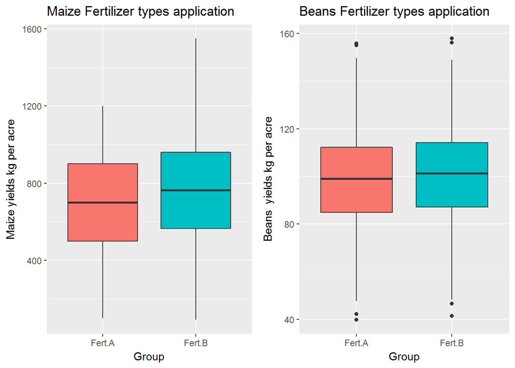

```r
# data  visualization for outlier check

g1 <- ggplot(c, aes(x=Group, y=Maize.yield.per.acre, fill=Group)) + geom_boxplot() +
    guides(fill=FALSE) + ylab("Maize yields kg per acre")+ggtitle("Maize Fertilizer types application")

g2 <- ggplot(c, aes(x=Group, y=Beans.yield.per.acre, fill=Group)) + geom_boxplot() +
    guides(fill=FALSE) + ylab("Beans  yields kg per acre")+ggtitle("Beans Fertilizer types application")

grid.arrange(g1, g2, ncol=2)
```

Typically, box-plot allow us to see the distribution of a variable data and whether they contain outliers or not. Indeed, those plotted box-lots are helping us see the performance of Fert.A and Fert.B on Maize and Beans Yields(kg) per Acre.Results revealed that Fert.B has good performance compared to Fert.A for both Maize and Beans yields. But in this particular case, box plots have helped to investigate something specific. It reveals some information on the outliers for beans yields that there’re large numbers of kg that max out near 160 for both fertilizer types and also has some outlier points at the low end .

Since some of the Beans data are unusual compared to the others which can have strong influence on the results, we should try to identify the cause of the unusual nature points. we can however choose to correct any data entry or measurement error, then consider removing data that are associated with special causes and repeating analysis.

### 5.1.2 Test of normality of data

#### 5.1.2.1 QQ-plot

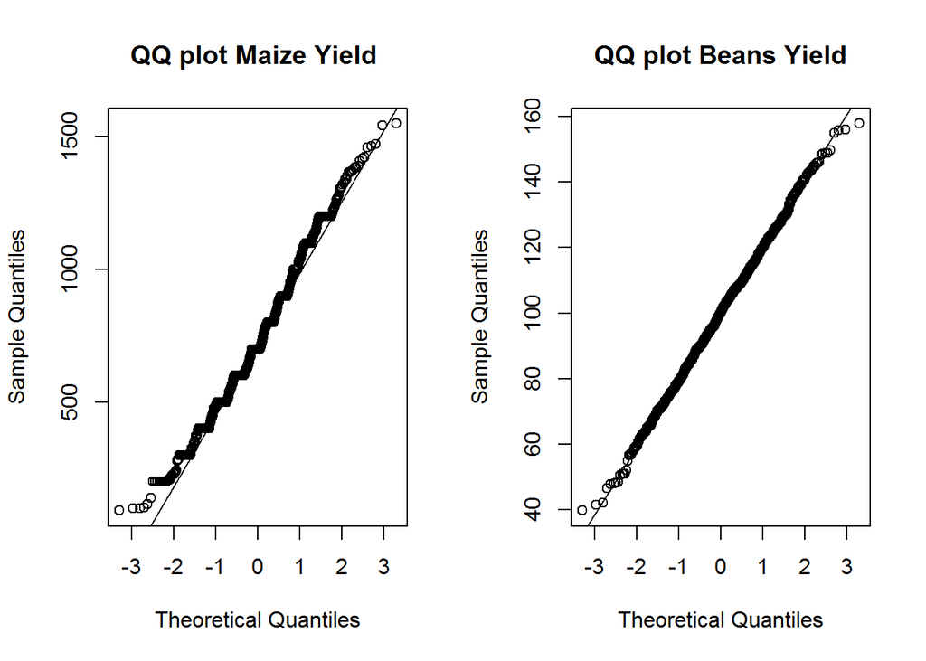

```r
# QQ plot  all data ( both group togetheer )

par(mfrow = c(1, 2))
qqnorm(c$Maize.yield.per.acre, main="QQ plot Maize Yield ")
qqline(c$Maize.yield.per.acre)

qqnorm(c$Beans.yield.per.acre, main="QQ plot Beans Yield")
qqline(c$Beans.yield.per.acre)
```

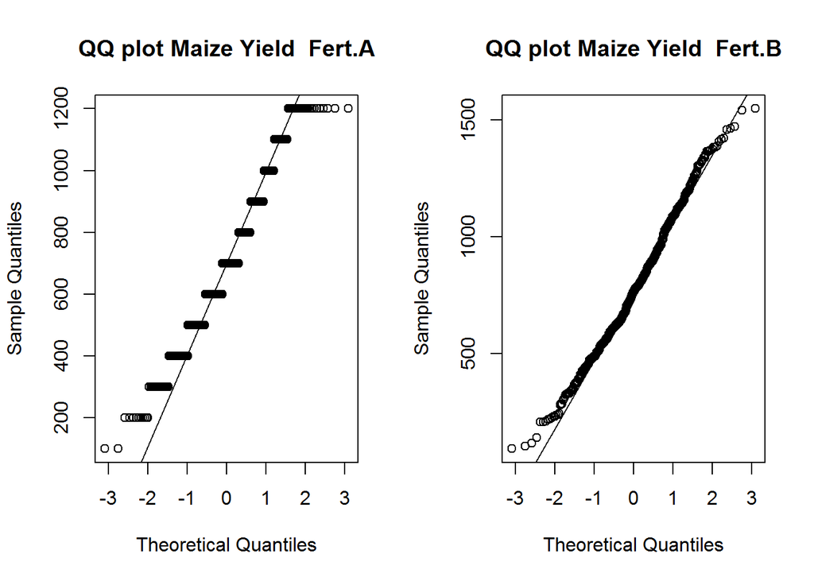

```r
## QQ-plots for subgroup
## create subsets

c1 <- subset(c,Group=="Fert.A", select=ID:Group)
c2 <- subset(c,Group=="Fert.B", select=ID:Group)

### maize
par(mfrow = c(1, 2))
qqnorm(c1$Maize.yield.per.acre, main="QQ plot Maize Yield  Fert.A")
qqline(c1$Maize.yield.per.acre)

qqnorm(c2$Maize.yield.per.acre, main="QQ plot Maize Yield  Fert.B")
qqline(c2$Maize.yield.per.acre)
```

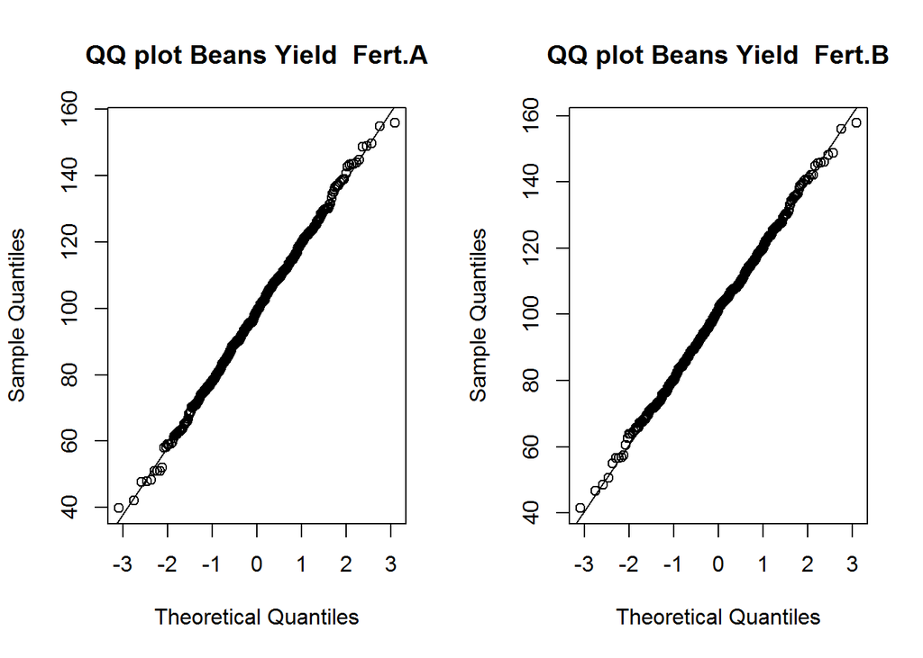

```r
### Beans
par(mfrow = c(1, 2))
qqnorm(c1$Beans.yield.per.acre, main="QQ plot Beans Yield  Fert.A")
qqline(c1$Beans.yield.per.acre)

qqnorm(c2$Beans.yield.per.acre, main="QQ plot Beans Yield  Fert.B")
qqline(c2$Beans.yield.per.acre)
```

As QQ-plot plots a perfect normal distribution as a solid diagonal line and then our actual data as markers (circles) on top of that. Therefore, the plotted entire data(Fert A&B) for beans yield shows some normal distribution while Maize yield data shows non-normal distribution trend.

However the plots look well when data are plotted in subgroups. The QQ-plots for Beans show that both Fert.A and Fert.B data follow a normal distribution while examining the data in plot of Maize yield,Fertilizer A has some larger deviation(its actual points deviate from the normal line ) than Fert.B .

How do we be sure with this discrepancy? Le’s run Shapiro test to see whether those systematic deviations from the normal line exist or not .

#### 5.1.2.2 Shapiro-Wilk normality test

```r
## Shapiro test
## Just to remember that c is  a dataframe for all groups data, c1 is subset for Fert.A only ,c2 IS for Fer.B

shapiro.test(c$Maize.yield.per.acre)
```

```
##
##  Shapiro-Wilk normality test
##
## data:  c$Maize.yield.per.acre
## W = 0.98692, p-value = 8.648e-08
```

```r
shapiro.test(c$Beans.yield.per.acre)
```

```
##
##  Shapiro-Wilk normality test
##
## data:  c$Beans.yield.per.acre
## W = 0.99885, p-value = 0.7881
```

```r
shapiro.test(c1$Maize.yield.per.acre)
```

```
##
##  Shapiro-Wilk normality test
##
## data:  c1$Maize.yield.per.acre
## W = 0.96851, p-value = 6.984e-09
```

```r
shapiro.test(c2$Maize.yield.per.acre)
```

```
##
##  Shapiro-Wilk normality test
##
## data:  c2$Maize.yield.per.acre
## W = 0.99071, p-value = 0.003069
```

```r
shapiro.test(c1$Beans.yield.per.acre)
```

```
##
##  Shapiro-Wilk normality test
##
## data:  c1$Beans.yield.per.acre
## W = 0.99846, p-value = 0.9433
```

```r
shapiro.test(c2$Beans.yield.per.acre)
```

```
##
##  Shapiro-Wilk normality test
##
## data:  c2$Beans.yield.per.acre
## W = 0.99873, p-value = 0.9798
```

Our Maize yields distribution has a Shapiro test P-value <5% for all Fertilizer types A&B tested separately and when tested both together. This is strongly suggests that our Maize data is non- normal. While Beans yields data, Shapiro test P-Values > 5% this indicates that data are normal.

## 5.2 Test of Significance

Since the results from Shapiro test suggests the normality for Beans Data and non-normal for Maize data, it is recommended to use different test statistic. Non-parametric test is recommended for non-normal data, vs parametric test when data are normal. Therefore ,to test the mean difference between Fert.A and fert B for Beans data which are normal , Welch Test( An improvement on the T-test, which is more robust to unequal variances) is recommended while the Wilcoxon Test is recommended for Maize Yield data that are not normal.

### 5.2.1 Welch Test for Beans Yield Data

```r
## Welch Test
t.test(Beans.yield.per.acre~Group, alternative = "two.sided", var.equal = FALSE, data=c)$p.value #perform the Welch test and store p-value
```

```
## [1] 0.1649692
```

```r
## Let us verify results using T test

t.test(Beans.yield.per.acre~Group, alternative = "two.sided", var.equal = TRUE, data=c)$p.value # We have gotten similar result because the variance is almost the same
```

```
## [1] 0.1649688
```

No siginficance difference mean yield found between two types of fertilizer applied to Beans ( Welch Test p-values>5%)

### 5.2.2 Wilcoxon Test for Maize Yield Data

```r
## Wilcoxon Test

wilcox.test(Maize.yield.per.acre~Group,paired=FALSE, correct=TRUE,data=c)
```

```
##
##  Wilcoxon rank sum test with continuity correction
##
## data:  Maize.yield.per.acre by Group
## W = 106400, p-value = 4.565e-05
## alternative hypothesis: true location shift is not equal to 0
```

```r
## let us verify results using T.test
t.test(Maize.yield.per.acre~Group, alternative = "two.sided", var.equal = TRUE, data=c) # has produce significance which should not be always promises , we must  use the right test at the right time.
```

```
##
##  Two Sample t-test
##
## data:  Maize.yield.per.acre by Group
## t = -4.3572, df = 998, p-value = 1.454e-05
## alternative hypothesis: true difference in means is not equal to 0
## 95 percent confidence interval:
##  -107.96710  -40.91513
## sample estimates:
## mean in group Fert.A mean in group Fert.B
##             698.6000             773.0411
```

We found a statistically significance mean yield difference between two types of fertilizer applied to Maize ( Wilcoxon Test p-values<5%)

## 5.3 Power Analysis

Our results have shown no difference in mean yield for Beans among Fertilizer A and B ( Welch test P-values=0.165 > 5%) and found to have statistically significant difference for Maize (Wilcoxon Test p-value = 4.565e-05 <5%) . However , there is a need of performing power calculations to assess whether the presence or lack of impact difference is due to the sample size, inherent to the intervention itself, or due to some other reason such as implementation failure or something else.

### 5.3.1 Power calculation

It is important that we use the correct power calculation in much the same way it is important we use the right hypothesis test.A low power will mean our results are less reliable and we may be making false conclusions about interventions.The required sample size to detect the effect of interest will need to produce the power of 0.8 and above . Power calculations are depending on the data distribution .Therefore with normal data ,* pwr.2p2n.test* will be used while *Mcpower* will be used for Non normal data .

Also since sample size, power and effect size are all part of the same equation and all related, We will first need to calculate effect size which is difference in means between samples divided by the standard deviation of the samples using *Cohen’s D equation* .

#### 5.3.1.1 Power Calculation for normal ( Beans Yield )

```r
# Generate effect size using Cohen D equation  (Note that c1 is dataframe that contain Data for Fert.A while c2 contain data for Fert.B)
#Don't forget to re run the command that generate c1 and c2 in above codes

cohen_d <- function(d1,d2) {
  m1 <- mean(d1, na.rm=TRUE)
  m2 <- mean(d2, na.rm=TRUE)
  s1 <- sd(d1, na.rm=TRUE)
  s2 <- sd(d2, na.rm=TRUE)
  spo <- sqrt((s1**2 + s2**2)/2)
  d <- (m1 - m2)/spo
  effsi <- d / sqrt((d**2)+4)
  ret <- list("d" = d, "effectsi" = effsi)
  return(ret)  }

##get effect size and call it like this:

vals<- cohen_d(c1$Beans.yield.per.acre, c2$Beans.yield.per.acre)

pwr.2p2n.test(h = vals$effectsi , n1 =length(c1$Group), n2=length(c2$Group) , sig.level = 0.05, power = NULL)
```

```
##
##      difference of proportion power calculation for binomial distribution (arcsine transformation)
##
##               h = 0.04389976
##              n1 = 500
##              n2 = 500
##       sig.level = 0.05
##           power = 0.10676
##     alternative = two.sided
##
## NOTE: different sample sizes
```

With the result calculated above , a statistical power of 0.106 was obtained , which means a weak power . Therefore ,it can be said with only 11% of certainly that there is no really a statistically significant difference between the beans’mean yields for two types of fertilizers . so we we can conclude that the sample size used was inappropriate for detecting whether meaningful effects have occurred or not. Given this risk, it is not acceptable to conclude that an intervention has not impact when the sample size used for the research is not sufficient to detect a meaningful difference between two types of fertilizer.

#### 5.3.1.2 Power calculation for Non-normal ( Maize Yield )

```r
MCpower = function(sample1, sample2, size) {
  reps = 1000
    results  <- sapply(1:reps, function(r) {
        resample1 <- sample(sample1, size=size, replace=TRUE)
        resample2 <- sample(sample2, size=size, replace=TRUE)
        test <- wilcox.test(resample1, resample2, alternative="two.sided",paired=FALSE, correct=TRUE)
        test$p.value
    })
    sum(results<0.05)/reps
}

 MCpower(c1$Maize.yield.per.acre, c2$Maize.yield.per.acre, 500)
```

```
## [1] 0.982
```

# 6 Follow up with Outlier for Beans Data

## 6.1 Run Outlier Check, QQ-plots and shapiro Test

Since our beans data has shown the outlier data points data, it is crucial to run again results to see if the outliers had any influential on the results .

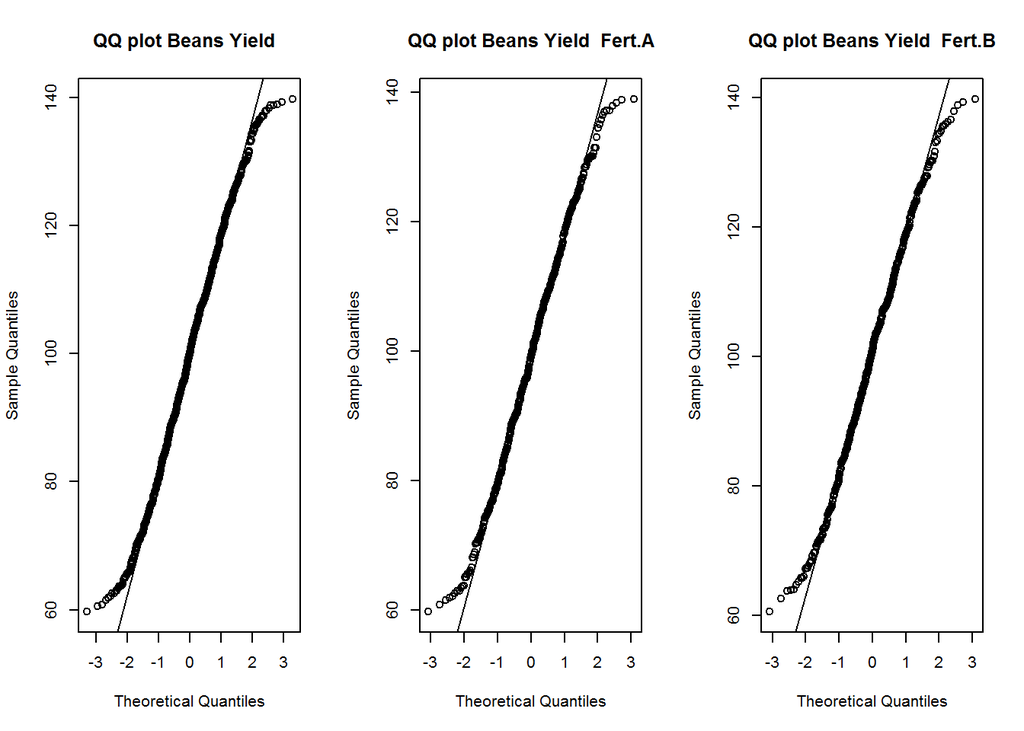

```r
## run outliers check function and detect it

outlier.check <- function(x) {

  name <- ifelse(x < (mean(x, na.rm=T)-(2*sd(x, na.rm=T))) |
                   x > (mean(x, na.rm=T) + (2*sd(x, na.rm=T))), 1, 0)

  return(name)
}

c$Beans_yield.check <- outlier.check(c$Beans.yield.per.acre)

## check again normality by considering outliers removal

##subset data without outliers

c0 <- subset(c,Beans_yield.check==0, select=ID:Beans_yield.check) ## all database without outliers
c3 <- subset(c0,Group=="Fert.A", select=ID:Beans_yield.check)     ## database for Fert A  without outliers
c4 <- subset(c0,Group=="Fert.B", select=ID:Beans_yield.check)     ## database for Fert B  without outliers
##
### qq-plots beans data with out outliers
par(mfrow = c(1,3))
qqnorm(c0$Beans.yield.per.acre, main="QQ plot Beans Yield  ")
qqline(c0$Beans.yield.per.acre)

qqnorm(c3$Beans.yield.per.acre, main="QQ plot Beans Yield  Fert.A")
qqline(c3$Beans.yield.per.acre)

qqnorm(c4$Beans.yield.per.acre, main="QQ plot Beans Yield  Fert.B")
qqline(c4$Beans.yield.per.acre)
```

```r
## Run Shapiro test for data with out outliers

shapiro.test(c0$Beans.yield.per.acre)
```

```
##
##  Shapiro-Wilk normality test
##
## data:  c0$Beans.yield.per.acre
## W = 0.99054, p-value = 8.536e-06
```

```r
shapiro.test(c3$Beans.yield.per.acre)
```

```
##
##  Shapiro-Wilk normality test
##
## data:  c3$Beans.yield.per.acre
## W = 0.99014, p-value = 0.002882
```

```r
shapiro.test(c4$Beans.yield.per.acre)
```

```
##
##  Shapiro-Wilk normality test
##
## data:  c4$Beans.yield.per.acre
## W = 0.99002, p-value = 0.002527
```

Huu, very interesting !!!. Those are some terrible when you look only on your data without taking into the oultiers . Some reality now start to happening .Before , shapiro test had shown us that data is normal , then the results have shown non -normal trend after removing outliers *shapiro test p-values <5%* which suggests us to use non parametric test .

## 6.2 Run Wilcoxon Test and Power Calculation

```r
## wicoxon test

wilcox.test(Beans.yield.per.acre~Group,paired=FALSE, correct=TRUE,data=c0)
```

```
##
##  Wilcoxon rank sum test with continuity correction
##
## data:  Beans.yield.per.acre by Group
## W = 108930, p-value = 0.3311
## alternative hypothesis: true location shift is not equal to 0
```

```r
## MCpower

MCpower = function(sample1, sample2, size) {
  reps = 1000
    results  <- sapply(1:reps, function(r) {
        resample1 <- sample(sample1, size=size, replace=TRUE)
        resample2 <- sample(sample2, size=size, replace=TRUE)
        test <- wilcox.test(resample1, resample2, alternative="two.sided",paired=FALSE, correct=TRUE)
        test$p.value
    })
    sum(results<0.05)/reps
}

 MCpower(c3$Beans.yield.per.acre, c4$Beans.yield.per.acre, 500)  ## number of database are not equal
```

```
## [1] 0.19
```

Now , we can conclude that there is no significance difference but sample size used for the research was not sufficient to detect a meaningful difference between two types of fertilizer.

# 7 Homework

*With Beans data , What is an optimal sample size required to detect minimum detectable effect (MDE) of interest since we know that having a sample size smaller than statistically required increases the likelihood of researchers concluding that the evaluated intervention has no impact when the intervention does Also for cost efficiency and value-for-money it is important to ensure that an evaluation research design does not use a larger sample size than is required to detect the minimum detectable effect (MDE) of interest*

# 8 Summary Stats for Reporting

```r
## for normal data , report means and confidence Interval
library(rcompanion)

groupwiseMean(Beans.yield.per.acre ~ Group,
              data   = c,
              conf   = 0.95,
              digits = 3)
```

```
##    Group   n  Mean Conf.level Trad.lower Trad.upper
## 1 Fert.A 500  98.9       0.95       97.1        101
## 2 Fert.B 500 101.0       0.95       98.9        102
```

```r
## for Non normal data ,report Median and ( 1st and 3rd quartiles)

setnames(c, old = c('Maize.yield.per.acre'),new = c('MaizeYield')) ## keep variable name short

aggregate(MaizeYield ~ Group, data = c, summary)
```

```
##    Group MaizeYield.Min. MaizeYield.1st Qu. MaizeYield.Median
## 1 Fert.A          100.00             500.00            700.00
## 2 Fert.B           91.14             564.40            762.70
##   MaizeYield.Mean MaizeYield.3rd Qu. MaizeYield.Max.
## 1          698.60             900.00         1200.00
## 2          773.00             961.00         1549.00
```